# Bonus Assignment

### Data Visualization for GitHub Issues

Author: Atef Bader Last Edit: 11/24/2018

# GitHub

[figure not shown]

# Deliverables:

- Submit a single zip-compressed file that has the name: YourLastName_Bonus_Assignment_1 that has the following files:
  1. Your **PDF document** that has your Source code and output
  2. Your **ipynb script** that has your Source code and output

# Objectives:

- Learn how to process data stored in **JSON** file
- Learn how to visualize data in **Stacked Chart**
- Learn how to plot data on **HeatMap**

# Submission Formats :

Create a folder or directory with all supplementary files with your last name at the beginning of the folder name, compress that folder with zip compression, and post the zip-archived folder under the assignment link in Canvas. The following files should be included in an archive folder/directory that is uploaded as a single zip-compressed file. (Use zip, not StuffIt or any 7z or any other compression method.)

1. Complete IPYNB script that has the source code in Python used to access and analyze the data. The code should be submitted as an IPYNB script that can be be loaded and run in Jupyter Notebook for Python
2. Output from the program, such as console listing/logs, text files, and graphics output for visualizations.
3. List file names and descriptions of files in the zip-compressed folder/directory.

Formatting Python Code When programming in Python, refer to Kenneth Reitz’ PEP 8: The Style Guide for Python Code: http://pep8.org/ (Links to an external site.)Links to an external site. There is the Google style guide for Python at https://google.github.io/styleguide/pyguide.html (Links to an external site.)Links to an external site. Comment often and in detail.

# GitHub Facts

[figure not shown]

# Microsoft acquired GitHub for $7.5 Billion in 2018

[figure not shown]

# Documentation of GitHub Issues

Tutorial and Documentation on how issues are created and managed on GitHub can be found at this URL :

**[Managing GitHub Issues](https://help.github.com/categories/managing-your-work-on-github/)**

# Data Viualization for GitGub Issues

In this assignment you will learn how to plot the Graph for sample data of GitHub issues with different labels created and closed on different dates for a sample of data created for experimental purposes on GitHub

### Examples of Issue Form Filled out

"issue_number": 1219, "created_at": "2018-07-11", "closed_at": "2018-08-12", "labels": ["Address:111 W Jackson Blvd Chicago 60604", "Category:Bug", "DetectionPhase:Design", "OriginationPhase:Design", "Priority:Critical", "Status:Approved"], "State": "closed", "Author": "SEngineer68H" "issue_number": 11, "created_at": "2018-01-09", "closed_at": null, "labels": ["Address:600 E GRAND AVE", "Category:Bug", "DetectionPhase:Testing", "Latitude:41.891551", "Longitude:-87.607375", "OriginationPhase:Testing", "Priority:Critical", "Status:Approved"], "State": "open", "Author": "HEngineer69D"

### Data Set File: issues.json

```python
import os

import _pickle as pickle

import pandas as pd                                    # panda's nickname is pd

import numpy as np                                     # numpy as np

from pandas import DataFrame, Series                   # for convenience

import matplotlib.pyplot as plt

%matplotlib inline
```

# Reading the Dataset stored in JSON file :

Lets read the issues from the JSON file and plot them in a stacked chart

```python
# Read the JSON file and load the data into a list of dictionaries

import json

list_of_issues_dict_data = [json.loads(line) for line in open('GitHub_issues.json')]
```

```python
# Create the DataFrame object for the list_of_issues_dict_data object

issues_df = DataFrame(list_of_issues_dict_data)
```

```python
# Sanity test: print first 5 rows in our DataFrame

issues_df.head()
```

|  | Author | State | closed_at | created_at | issue_number | labels |
| --- | --- | --- | --- | --- | --- | --- |
| 0 | SPM587SP18 | closed | 2018-04-09 | 2018-04-02 | 803 | [Address:2525 S Martin Luther King Drive, Cate... |
| 1 | SPM587SP18 | closed | 2018-04-06 | 2018-03-30 | 802 | [Address:2525 S Martin Luther King Drive, Cate... |
| 2 | PEngineer54P | closed | 2018-08-10 | 2018-05-10 | 894 | [Address:111 W JACKSON, Category:Bug, Detectio... |
| 3 | PEngineer99P | closed | 2018-08-11 | 2018-04-10 | 891 | [Address:1919 Dempster Street, Category:Bug, D... |
| 4 | JEngineer54B | closed | 2018-08-11 | 2018-06-10 | 888 | [Address:1919 Dempster Street, Category:Bug, L... |

```python
# Prepare and Clean the dataframe object

wrangled_issues_df = issues_df[['Author','State','closed_at','created_at','issue_number']]
wrangled_issues_df.loc[0:len(wrangled_issues_df), 'OriginationPhase']= np.NaN

wrangled_issues_df.loc[0:len(wrangled_issues_df),'DetectionPhase']= np.NaN
wrangled_issues_df.loc[0:len(wrangled_issues_df),'Category']= np.NaN
wrangled_issues_df.loc[0:len(wrangled_issues_df),'Priority']= np.NaN
wrangled_issues_df.loc[0:len(wrangled_issues_df),'Status']= np.NaN
wrangled_issues_df.loc[0:len(wrangled_issues_df),'Address']= np.NaN
wrangled_issues_df.loc[0:len(wrangled_issues_df),'Latitude']= np.NaN
wrangled_issues_df.loc[0:len(wrangled_issues_df),'Longitude']= np.NaN
```

```python
#Sanity test the content of the datframe object

wrangled_issues_df.head()
```

|  | Author | State | closed_at | created_at | issue_number | OriginationPhase | DetectionPhase | Category | Priority | Status | Address | Latitude | Longitude |
| --- | --- | --- | --- | --- | --- | --- | --- | --- | --- | --- | --- | --- | --- |
| 0 | SPM587SP18 | closed | 2018-04-09 | 2018-04-02 | 803 | NaN | NaN | NaN | NaN | NaN | NaN | NaN | NaN |
| 1 | SPM587SP18 | closed | 2018-04-06 | 2018-03-30 | 802 | NaN | NaN | NaN | NaN | NaN | NaN | NaN | NaN |
| 2 | PEngineer54P | closed | 2018-08-10 | 2018-05-10 | 894 | NaN | NaN | NaN | NaN | NaN | NaN | NaN | NaN |
| 3 | PEngineer99P | closed | 2018-08-11 | 2018-04-10 | 891 | NaN | NaN | NaN | NaN | NaN | NaN | NaN | NaN |
| 4 | JEngineer54B | closed | 2018-08-11 | 2018-06-10 | 888 | NaN | NaN | NaN | NaN | NaN | NaN | NaN | NaN |

```python
# we need to create a list of the key:value pairs in labels

for i in range(0, len(issues_df)):

    if issues_df.iloc[i]['labels']:
        for label in issues_df.iloc[i]['labels']:
#            print(label)
            label_name= (label.split(':'))[0]
            label_value= (label.split(':'))[1]
            wrangled_issues_df.loc[i, label_name]=label_value
```

```python
#Sanity test the content of the datframe object

wrangled_issues_df.head()
```

|  | Author | State | closed_at | created_at | issue_number | OriginationPhase | DetectionPhase | Category | Priority | Status | Address | Latitude | Longitude |
| --- | --- | --- | --- | --- | --- | --- | --- | --- | --- | --- | --- | --- | --- |
| 0 | SPM587SP18 | closed | 2018-04-09 | 2018-04-02 | 803 | Design | Testing | Bug | Critical | Rejected | 2525 S Martin Luther King Drive | 41.853136 | -87.633160 |
| 1 | SPM587SP18 | closed | 2018-04-06 | 2018-03-30 | 802 | Design | Testing | Bug | Critical | Rejected | 2525 S Martin Luther King Drive | 41.853136 | -87.633160 |
| 2 | PEngineer54P | closed | 2018-08-10 | 2018-05-10 | 894 | Requirements | Design | Bug | Medium | Approved | 111 W JACKSON | 41.877817 | -87.631247 |
| 3 | PEngineer99P | closed | 2018-08-11 | 2018-04-10 | 891 | Design | Design | Bug | Medium | pendingReview | 1919 Dempster Street | 42.041392 | -87.700113 |
| 4 | JEngineer54B | closed | 2018-08-11 | 2018-06-10 | 888 | NaN | NaN | Bug | NaN | NaN | 1919 Dempster Street | 42.041392 | -87.700113 |

### Plot in Stacked Bar Chart the total number of issues created every day for every Detaction Phase

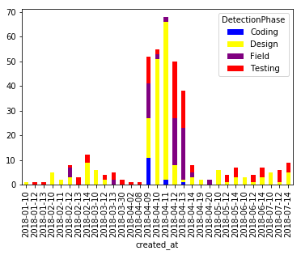

```python
github_issues_by_date_created_detectionphase = wrangled_issues_df.groupby(['created_at','DetectionPhase']).created_at.count()

github_issues_by_date_created_detectionphase_fig = github_issues_by_date_created_detectionphase.unstack().plot(kind='bar',stacked=True,  color=['blue','yellow', 'purple', 'red', 'green'], grid=False)
```

### Plot in Stacked Bar Chart the total number of issues created for detection Phase based on thier priorites

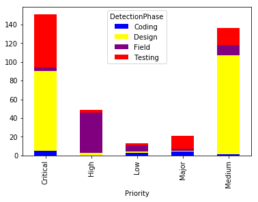

```python
# Plot in Stacked Bar Chart the total number of issues created for detection Phase based on thier priorites

github_issues_by_priority_detectionphase = wrangled_issues_df.groupby(['Priority','DetectionPhase']).created_at.count()

github_issues_by_priority_detectionphase_fig = github_issues_by_priority_detectionphase.unstack().plot(kind='bar',stacked=True,  color=['blue','yellow', 'purple', 'red', 'green'], grid=False)
```

### Plot in Stacked Bar Chart the total number of issues closed every day for every Category

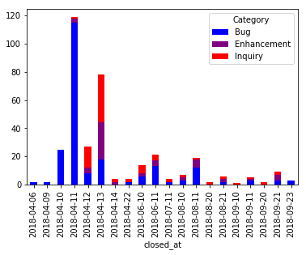

```python
github_issues_by_closed_date_category = wrangled_issues_df.groupby(['closed_at','Category']).closed_at.count()

github_issues_by_closed_date_category_fig = github_issues_by_closed_date_category.unstack().plot(kind='bar',stacked=True,  color=['blue', 'purple', 'red'], grid=False)
```

# Lets plot the issues on a HeatMap

We will use Folium HeatMap to plot on a HeatMap our GitHub issues using Latitude and Longitude pairs. Here is the API documentation for Folium/HeatMap

**[Folium/HeatMap API](http://python-visualization.github.io/folium/docs-v0.5.0/plugins.html)**

Here is the command that you execute from the terminal window in order to install Folium:

- conda install -c conda-forge folium

```python
import folium
from folium import plugins
```

```python
# Lets take a VERTICAL SLICE  ['Latitude','Longitude'] of the dataframe object

df_lat_lng = wrangled_issues_df[['Latitude','Longitude']]
```

```python
#Sanity test the content of the datframe object

df_lat_lng.head()
```

|  | Latitude | Longitude |
| --- | --- | --- |
| 0 | 41.853136 | -87.633160 |
| 1 | 41.853136 | -87.633160 |
| 2 | 41.877817 | -87.631247 |
| 3 | 42.041392 | -87.700113 |
| 4 | 42.041392 | -87.700113 |

```python
# Lets create a list of ['Latitude','Longitude'] pairs to feed into the HeatMap object

github_issues_coord = []

for i in range(0, len(df_lat_lng)):
    location_ll = []
    if ( pd.notnull(df_lat_lng.iloc[i]['Latitude']) and  pd.notnull(df_lat_lng.iloc[i]['Longitude'])):
#        print(df_lat_lng.iloc[i]['Latitude'], df_lat_lng.iloc[i]['Longitude'])
        location_ll.append(float(df_lat_lng.iloc[i]['Latitude']))
        location_ll.append(float(df_lat_lng.iloc[i]['Longitude']))
        github_issues_coord.append(location_ll)
```

```python
github_issues_heat_map = folium.Map([41.891551, -87.607375],zoom_start = 16)
github_issues_heat_map.add_child(plugins.HeatMap(github_issues_coord,radius=15))

# interact with the map below by zooming in/out
# Experiment with zoom_start and radius parameters of the HeatMap by using differen values
```

[interactive chart not shown]

# Requirement #1:

Plot in Stacked Bar Chart the total number of issues closed every day for every Origination Phase

```python
wrangled_issues_df.head()
```

|  | Author | State | closed_at | created_at | issue_number | OriginationPhase | DetectionPhase | Category | Priority | Status | Address | Latitude | Longitude |
| --- | --- | --- | --- | --- | --- | --- | --- | --- | --- | --- | --- | --- | --- |
| 0 | SPM587SP18 | closed | 2018-04-09 | 2018-04-02 | 803 | Design | Testing | Bug | Critical | Rejected | 2525 S Martin Luther King Drive | 41.853136 | -87.633160 |
| 1 | SPM587SP18 | closed | 2018-04-06 | 2018-03-30 | 802 | Design | Testing | Bug | Critical | Rejected | 2525 S Martin Luther King Drive | 41.853136 | -87.633160 |
| 2 | PEngineer54P | closed | 2018-08-10 | 2018-05-10 | 894 | Requirements | Design | Bug | Medium | Approved | 111 W JACKSON | 41.877817 | -87.631247 |
| 3 | PEngineer99P | closed | 2018-08-11 | 2018-04-10 | 891 | Design | Design | Bug | Medium | pendingReview | 1919 Dempster Street | 42.041392 | -87.700113 |
| 4 | JEngineer54B | closed | 2018-08-11 | 2018-06-10 | 888 | NaN | NaN | Bug | NaN | NaN | 1919 Dempster Street | 42.041392 | -87.700113 |

```python
wrangled_issues_df.OriginationPhase.unique()
```

```
array(['Design', 'Requirements', nan, 'Coding', 'Field', 'Documentation',
       'Testing'], dtype=object)
```

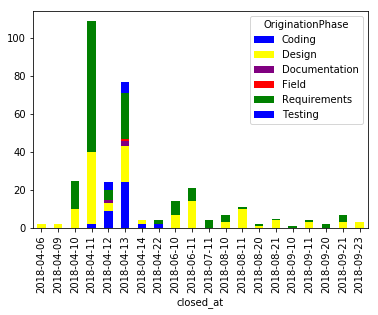

```python
github_issues_by_date_closed_OriginationPhase = wrangled_issues_df.groupby(['closed_at','OriginationPhase']).closed_at.count()

github_issues_by_date_closed_OriginationPhase_fig = github_issues_by_date_closed_OriginationPhase.unstack().plot(kind='bar',stacked=True,  color=['blue','yellow', 'purple', 'red', 'green'], grid=False)
```

# Requirement #2:

Plot in Stacked Bar Chart the total number of issues created for every Phase based on their Status

```python
wrangled_issues_df.Status.unique()
```

```
array(['Rejected', 'Approved', 'pendingReview', nan, 'inProgress',
       'Completed'], dtype=object)
```

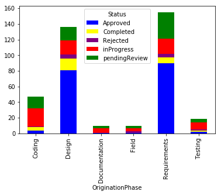

```python
github_issues_by_date_created_phase_status = wrangled_issues_df.groupby(['OriginationPhase', 'Status']).created_at.count()
github_issues_by_date_created_phase_status_fig = github_issues_by_date_created_phase_status.unstack().plot(kind='bar',stacked=True,  color=['blue','yellow', 'purple', 'red', 'green'], grid=False)
```

# Requirement #3:

Create Folium HeatMap for issues that have Priority equals to Critical

```python
def valid_loc( df, index ):
    return pd.notnull(df.iloc[index]['Latitude']) and pd.notnull(df.iloc[index]['Longitude'])
```

```python
def extract_coords( df ):
    results = []

    for i in range(0, len(df)):
        x = float(df.iloc[i]['Latitude'])
        y = float(df.iloc[i]['Longitude'])

        results.append([x ,y ])

    return results
```

```python
req3_df = wrangled_issues_df[['Latitude','Longitude', 'Priority']]
req3_df.head()
```

|  | Latitude | Longitude | Priority |
| --- | --- | --- | --- |
| 0 | 41.853136 | -87.633160 | Critical |
| 1 | 41.853136 | -87.633160 | Critical |
| 2 | 41.877817 | -87.631247 | Medium |
| 3 | 42.041392 | -87.700113 | Medium |
| 4 | 42.041392 | -87.700113 | NaN |

```python
crit_flag = (req3_df['Priority'] == 'Critical')
```

```python
req3_df = req3_df[ crit_flag ]
```

```python
req3_df = req3_df.dropna()
```

### Ensure ALL issues are only of (only) critical priority.

```python
req_3_values = req3_df.Priority.unique()
```

```python
assert len(req_3_values) == 1
assert req_3_values[0] == 'Critical'
```

### Map it.

```python
req3_coord = extract_coords(req3_df)
```

```python
req3_pos = list(zip(*req3_coord))
```

```python
req3_map = folium.Map([np.mean(req3_pos[0]), np.mean(req3_pos[1])], zoom_start=12)
req3_map.add_child(plugins.HeatMap(req3_coord, radius=15))
```

[interactive chart not shown]

# Requirement #4:

Create Folium HeatMap for issues that have Priority equals to Critical or High AND Status is Approved or inProgress

```python
req4_df = wrangled_issues_df[['Latitude','Longitude', 'Priority', 'Status']]
req4_df.head()
```

|  | Latitude | Longitude | Priority | Status |
| --- | --- | --- | --- | --- |
| 0 | 41.853136 | -87.633160 | Critical | Rejected |
| 1 | 41.853136 | -87.633160 | Critical | Rejected |
| 2 | 41.877817 | -87.631247 | Medium | Approved |
| 3 | 42.041392 | -87.700113 | Medium | pendingReview |
| 4 | 42.041392 | -87.700113 | NaN | NaN |

```python
priority_flag = req4_df['Priority'].isin(['Critical', 'High'])
```

```python
status_flag = req4_df['Status'].isin(['Approved', 'inProgress'])
```

```python
req4_df = req4_df[ priority_flag & status_flag ]
```

```python
req4_df = req4_df.dropna()
```

### Ensure columns values are all of the expected type.

```python
assert np.array_equal( req4_df.Priority.unique(), ['Critical', 'High'] )
```

```python
assert np.array_equal( req4_df.Status.unique(), ['Approved', 'inProgress'] )
```

### Map it.

```python
req4_coord = extract_coords(req4_df)
```

```python
req4_pos = list(zip(*req4_coord))
```

```python
critical_status_heat_map = folium.Map([np.mean(req4_pos[0]), np.mean(req4_pos[1])], zoom_start=12)
critical_status_heat_map.add_child(plugins.HeatMap(req4_coord, radius=15))
```

[interactive chart not shown]

# Requirement #5:

Create Folium HeatMap for issues that have Field as the DetectionPhase and created during the month of April, 2018.

```python
req5_df = wrangled_issues_df[['Latitude','Longitude', 'DetectionPhase', 'created_at']]
req5_df.head()
```

|  | Latitude | Longitude | DetectionPhase | created_at |
| --- | --- | --- | --- | --- |
| 0 | 41.853136 | -87.633160 | Testing | 2018-04-02 |
| 1 | 41.853136 | -87.633160 | Testing | 2018-03-30 |
| 2 | 41.877817 | -87.631247 | Design | 2018-05-10 |
| 3 | 42.041392 | -87.700113 | Design | 2018-04-10 |
| 4 | 42.041392 | -87.700113 | NaN | 2018-06-10 |

```python
req5_df['date'] = pd.to_datetime(req5_df['created_at'])
```

```python
req5_df = req5_df.drop('created_at',axis=1)
```

```python
date_filter = (req5_df['date'] > '3/30/18') & (req5_df['date'] <= '5/1/18')
```

```python
req5_df = req5_df[date_filter]
```

```python
phase_filter = (req5_df['DetectionPhase'] == 'Field')
```

```python
req5_df = req5_df[phase_filter]
```

```python
req5_df = req5_df.dropna()
```

### Ensure df has only expected values.

```python
month_values = req5_df['date'].map(lambda x: x.month).unique()
```

```python
assert len(month_values) == 1
assert month_values[0] == 4
```

```python
phases = req5_df.DetectionPhase.unique()

assert len(phases) == 1
assert phases[0] == 'Field'
```

### Map it.

```python
req5_coord = extract_coords(req5_df)
```

```python
req5_pos = list(zip(*req5_coord))
```

```python
req5_map = folium.Map([np.mean(req5_pos[0]), np.mean(req5_pos[1])], zoom_start = 12)
req5_map.add_child(plugins.HeatMap(req5_coord,radius=15))
```

[interactive chart not shown]